# Clase 2.0 Gráficos básicos

Estadística y Manejo de Datos con R (EMDR) — Virtual

## Gráficos básicos en R

## Gráficos en R

- Una de las características más atractivas de R es la representación gráfica de datos.
- R cuenta con capacidad nativa de realizar un gran número de gráficos `demo(graphics)`.
- También hay paquetes que aumentan la calidad y el número de posibilidades paa graficar.

## Gráficos en R

- R divide sus funciones gráficas en dos conjuntos:
  - Las funciones de “alto nivel” se encargan de la creación de gráficos (la primera capa) a partir del principal cuerpo de datos
  - Las funciones de “bajo nivel” añaden otras capas de datos, textos y leyendas

## Gráficos en R

- `plot()` una función de **alto nivel**

```r
plot(x) # un vector
plot(x, y) # dos vectores
plot(f) # un factor
plot(df) # un data frame (marco de datos)
plot(y ~ expr)  # especificar categorías
```

## Gráficos en R

- `plot()` un vector

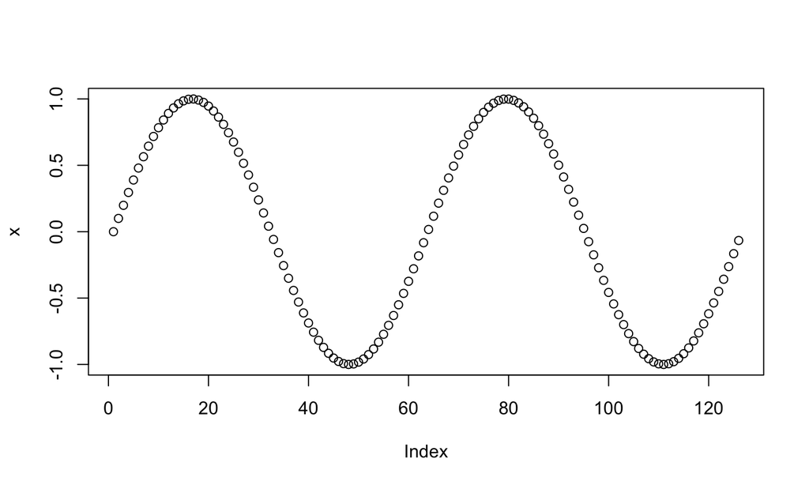

```r
x <- sin(seq(from = -2*pi, to = 2*pi, by = 0.1))
plot(x)
```

## Gráficos en R

- `plot()` dos vectores

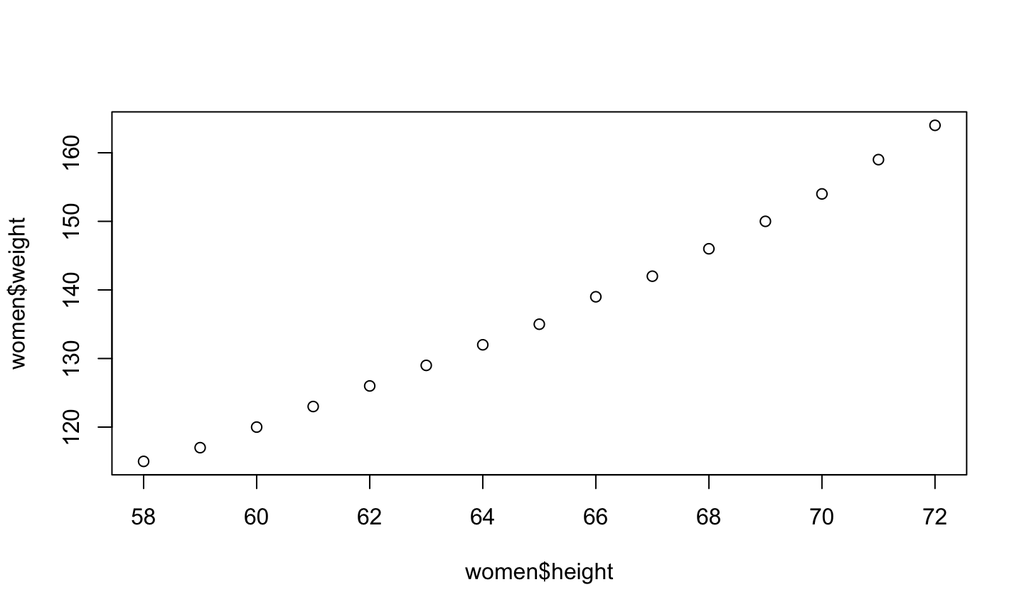

```r
data(women);
plot(women$height, women$weight)
```

## Gráficos en R

- `plot()` un factor

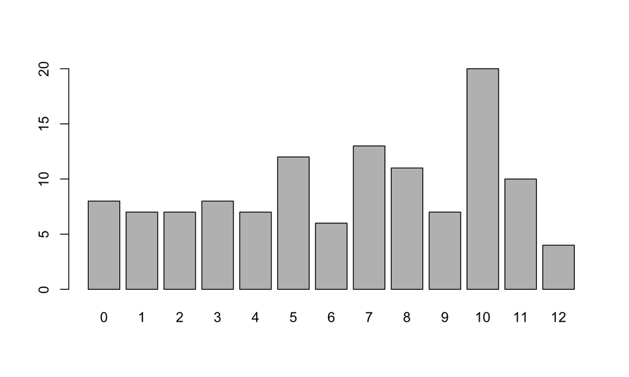

```r
x <- as.factor(round(runif(120, min = 0, max = 12)))
plot(x)
```

## Gráficos en R

- `plot()` un data frame con un factor

```r
df <- data.frame(scores = round(runif(120, min = 0, max = 12)),
                  cases = rep(letters[1:4], 30))
#plot(scores~cases, data = df)
```

## Gráficos en R

- `plot()` un data frame

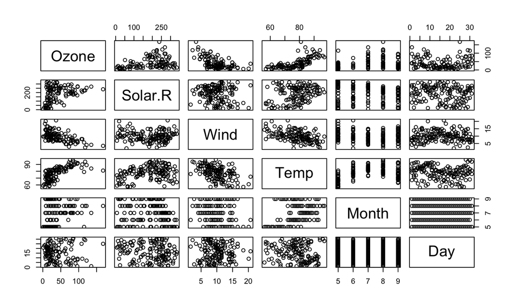

```r
plot(airquality)
```

## Gráficos en R

- Ejecuta `demo(graphics)` en tu consola para activar la demostración de gráficos incluidos en la paquetería básica de R.
  - Selecciona una opción y/o da “enter” para avanzar.
  - Los gráficos aparecen en la ventana de Plots.
  - El código es visible en la línea de comandos.

## Gráficos en R: Ejercicios

- Utiliza los datos de `ChickWeight` para generar el siguiente gráfico:

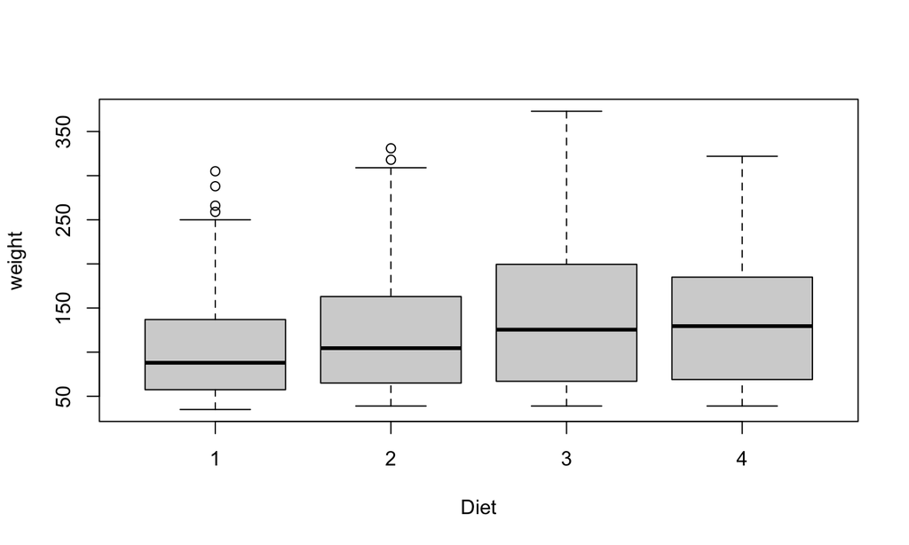

## Gráficos en R: Ejercicio

- Solución
  - Disponible después de la fecha de entrega.

## Gráficos en R

- `points()`, `lines()`, `abline()`, `text()`, `legend()`, `polygon()`, `title()`, `axis()` son todas ejemplos de funciones de **bajo nivel**.
- Con las funciones de bajo nivel añadimos información a un gráfico ya existente.
- Para ver los argumentos específicos de cada función se puede usa **help(nombref)** o **?nombref()** .
  - Por ejemplo: `help(points)` o `?points()`.

## Gráficos en R

- `points()` agrega **puntos** a un gráfico:

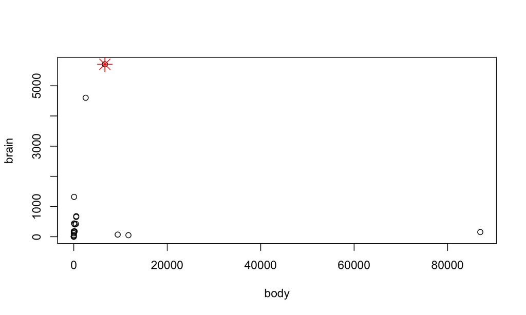

```r
data(Animals, package = "MASS")
plot(Animals)
points(Animals[rownames(Animals) == "African elephant", ],
       pch = 8, col = "red", cex = 2)
```

## Gráficos en R

- `lines()` agrega **líneas** a un gráfico:

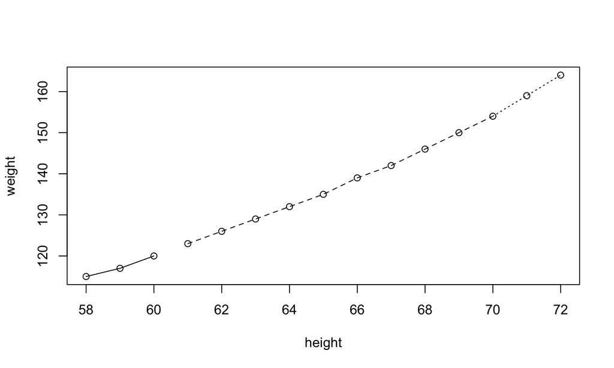

```r
plot(women)
lines(women[women$height <= 60, ], lty = 1)
lines(women[women$height >= 70, ], lty = 3)
lines(women[women$height > 60 & women$height <= 70,], lty = 2)
```

## Gráficos en R

- `text()` agrega **texto** a un gráfico:

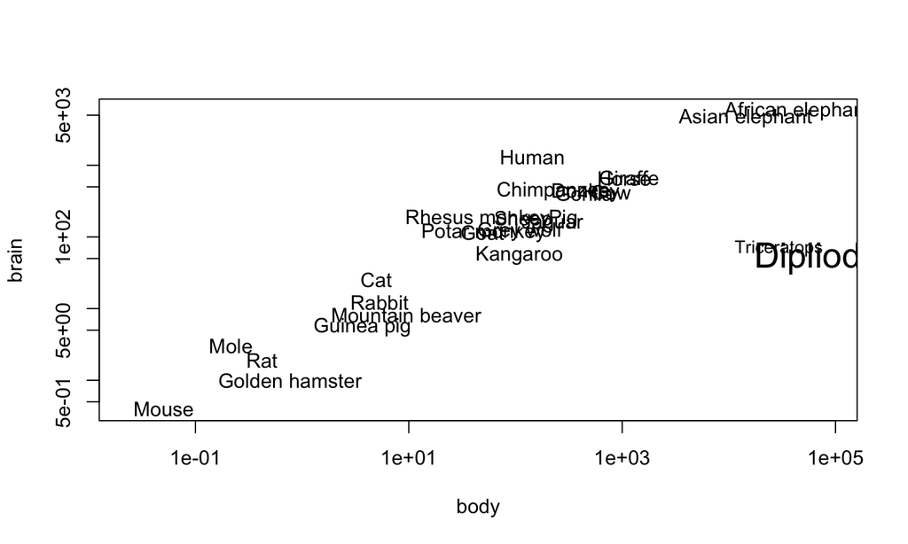

```r
plot(Animals, col = "white", log = c("xy"))
text(Animals, rownames(Animals),
      cex = scale(Animals$body/Animals$brain), adj = -0.1)
```

## Gráficos en R

- `abline()` agrega una **predicción lineal** a un gráfico:

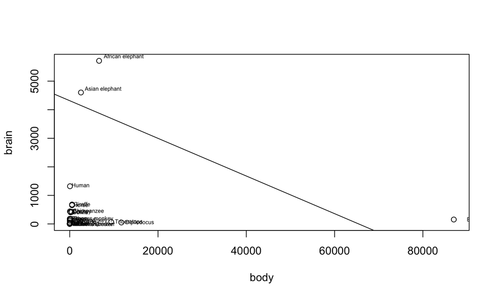

```r
plot(Animals)
text(Animals + Animals * 0.025, rownames(Animals), cex = 0.5, adj = -0.1)
abline(lm(Animals))
```

## Gráficos en R

- Un problema de ejes:

```r
plot(Animals)
abline(h=mean(Animals$brain))
abline(h=mean(Animals$brain) + sd(Animals$brain), lty = 3)
abline(h=mean(Animals$brain) - sd(Animals$brain), lty = 3)
```

- ¿Qué pasa con la segunda línea de desviación estándar?

## Gráficos en R

- Un problema de ejes:

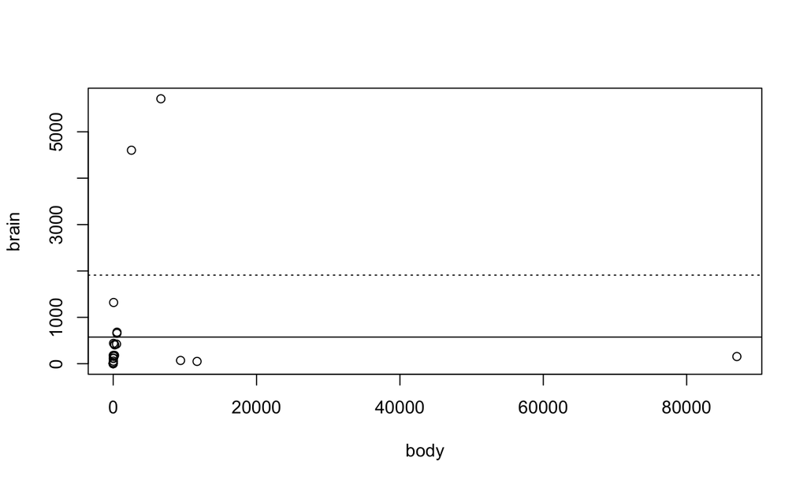

## Gráficos en R

- Modificamos los parámetros de `ylim =`

```r
plot(Animals, ylim = c(-1000, 6000))
abline(h=mean(Animals$brain))
abline(h=mean(Animals$brain) + sd(Animals$brain), lty = 3)
abline(h=mean(Animals$brain) - sd(Animals$brain), lty = 3)
```

## Gráficos en R

- Modificamos los parámetros de `ylim =`

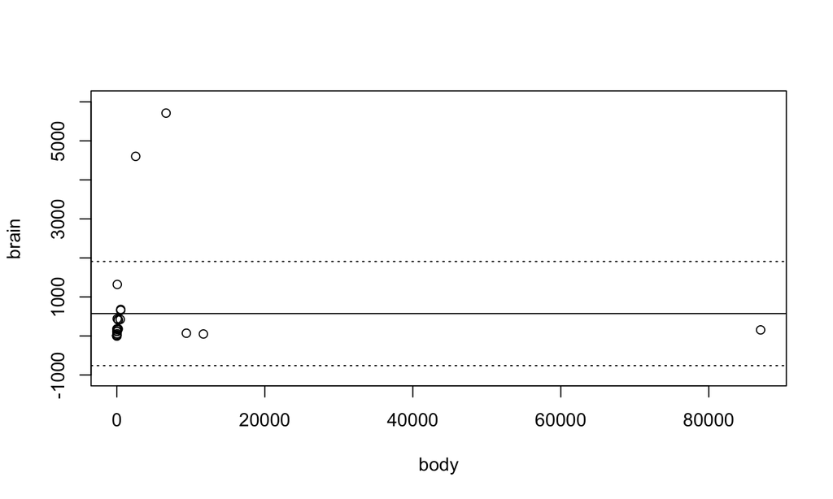

## Gráficos en R: Ejercicios

- Utiliza los datos de `Indometh` para generar el siguiente gráfico.
  - ¡Asigna un color por sujeto!
  - tip: `lines()`

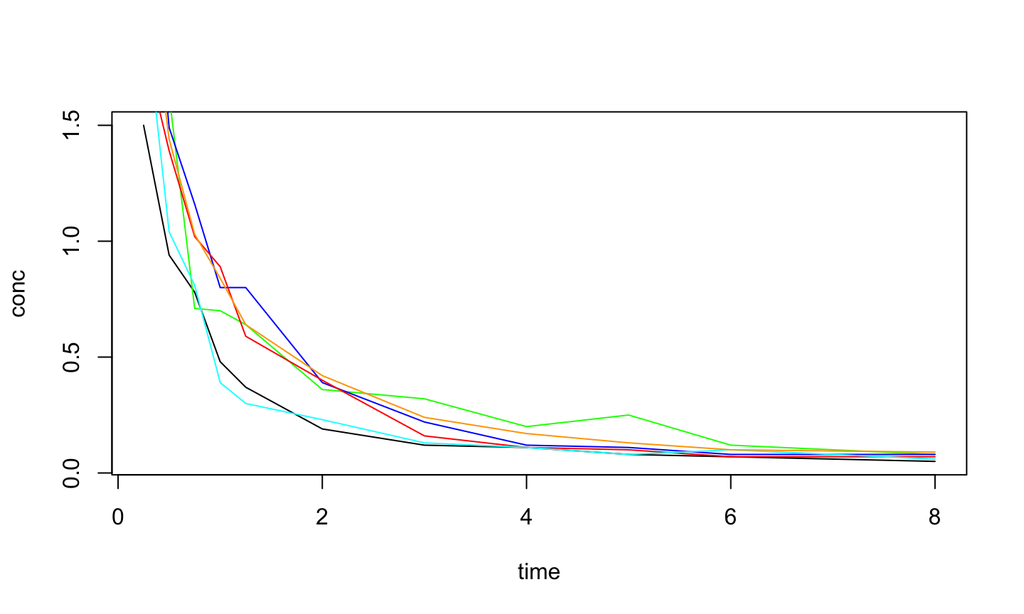

## Gráficos en R: Ejercicios

- Solución
  - Disponible después de la fecha de entrega.

## Gráficos en R

- La función `par()` permite modifcar todos los aspectos de un gráfico, desde el título hasta la distancia entre la graduación y las etiquetas en los ejes.
- Podemos usar **help** `?par()` para ver los parámetros específicos.
- Uno de los usos principales de `par()` es la construcción de múltiples gráficos en la misma figura.
- Para gráficos aún mas complejos, revisa la función `layout()`

## Gráficos en R

- `par()` y `mfrow =` controlan el número de gráficos por fila (multiple figures per row).

```r
par(mfrow = c(3,1))

h <- c("Hello", "World", "!")

plot(0, 0, col = "white", xlab = "", ylab = "")

text(0, 0, h[1], cex = 2)

plot(0, 0, col = "white", xlab = "", ylab = "")

text(0, 0, h[2], cex = 2)

plot(0, 0, col = "white", xlab = "", ylab = "")

text(0, 0, h[3], cex = 2)
```

## Gráficos en R

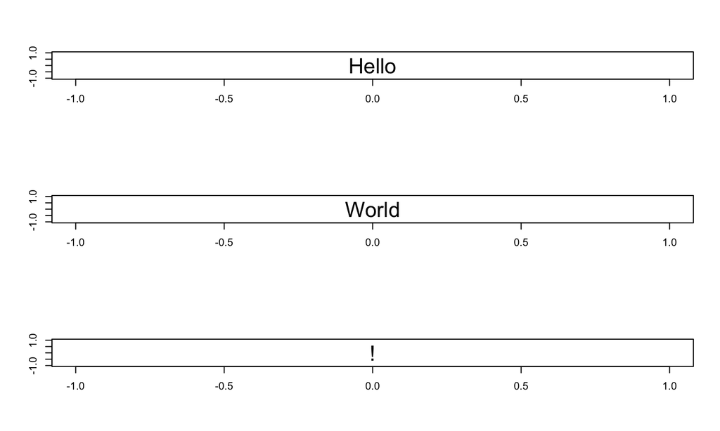

## Gráficos en R

- ¿Cómo guardar un gráfico?
  - Empezamos por el nombre y formato del gráfico:

  ```r
  pdf("mi_plot.pdf")
  ```

  - Imprimimos el gráfico:

  ```r
  plot(data)
  ```

  - Cerramos la conexión:

  ```r
  dev.off()
  ```

## Licencia CC BY

Estadística y Manejo de Datos con R (EMDR) por Marcos F. Rosetti S. y Luis Pacheco-Cobos se distribuye bajo una [Licencia Creative Commons Atribución 4.0 Internacional](http://creativecommons.org/licenses/by/4.0/).